# Homework

Tom IHro

2023-11-21

```r
library("terra")
hym = rast("Data/HyMap_125bands_Karlsruhe2.tif")
hym = hym/100

tree = vect("Data/tree_species_KA.shp")
```

## Task 1

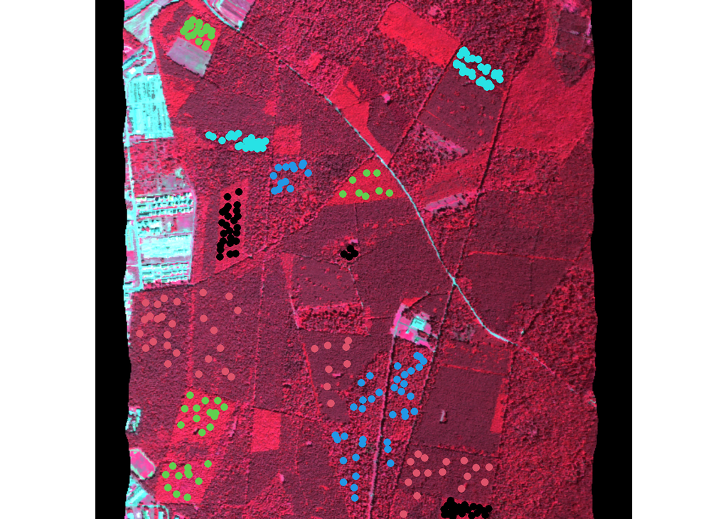

```r
plotRGB(hym,22,14,8,stretch = "lin",range=c(0,100))

plot(tree,col=tree$id,add = TRUE)
```

## Task 2

The Carniferous forest are the darker forest here marked by pink markers for the test samples while the broad leafed forest brighter and marked by the light green points.

## Task 3

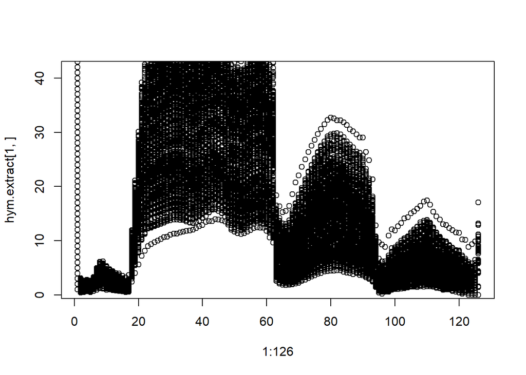

```r
hym.extract = extract(hym, tree)
xHelp = 1:126
plot(1:126,hym.extract[1,])
for(i in 1:250){
  points(1:126,hym.extract[i,])
}
```

## Task 4

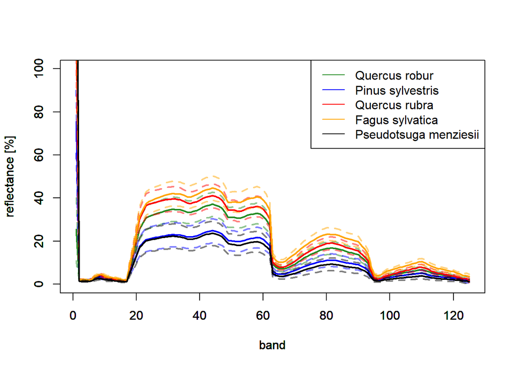

```r
hym.extract$species = tree$id

hym.extract.mean <- aggregate(hym.extract, hym.extract[,"species", drop=FALSE], mean)
hym.extract.sd <- aggregate(hym.extract, hym.extract[,"species", drop=FALSE], sd)


mycolors= c("forest green", "blue", "red", "orange", "black")
# plot the spectra for the first tree id and add the standard deviations

for (i in 1:5){
  plot(1:125, hym.extract.mean[i, 2:126], type="l", col=mycolors[i], ylim=c(0,100), lwd=2, xlab= "band", ylab="reflectance [%]")
  # plot mean spectral signature + sd values
  lines(1:125, hym.extract.mean[i, 2:126]+hym.extract.sd[1,2:126], col=adjustcolor(mycolors[i], alpha.f=0.5), lty=2, lwd=2)
  # plot mean spectral signature - sd values
  lines(1:125, hym.extract.mean[i, 2:126]-hym.extract.sd[1, 2:126],  col=adjustcolor(mycolors[i], alpha.f=0.5), lty=2, lwd=2)
  par(new=T)
}

# add a legend indicating the species names
legend("topright", legend=c("Quercus robur", "Pinus sylvestris", "Quercus rubra", "Fagus sylvatica", "Pseudotsuga menziesii"), col=mycolors, lty=c(1,1,1,1,1))
```

## Task 5

This shows us that separating the tree species is not going to be easy as the all have a very similar spectrum differentiated only by the strength of different features.

```r
library("e1071")
gammas <-   2^(-8:5)
costs <- 2^(-5:8)
class.svm <- e1071::tune(svm,
              train.x = hym.extract[2:126],
              train.y = as.factor(hym.extract$species),
              type = "C-classification",
              kernel = "radial",
              scale = TRUE,
              ranges = list(gamma = gammas, cost = costs),
              tunecontrol = tune.control(cross = 5)
              )
# Have a look at the information of the svm models:
summary(class.svm)
```

```
##
## Parameter tuning of 'svm':
##
## - sampling method: 5-fold cross validation
##
## - best parameters:
##       gamma cost
##  0.00390625  128
##
## - best performance: 0.196
##
## - Detailed performance results:
##           gamma      cost error dispersion
## 1    0.00390625   0.03125 0.632 0.15401299
## 2    0.00781250   0.03125 0.620 0.14142136
```

[output cut: 194 more lines]

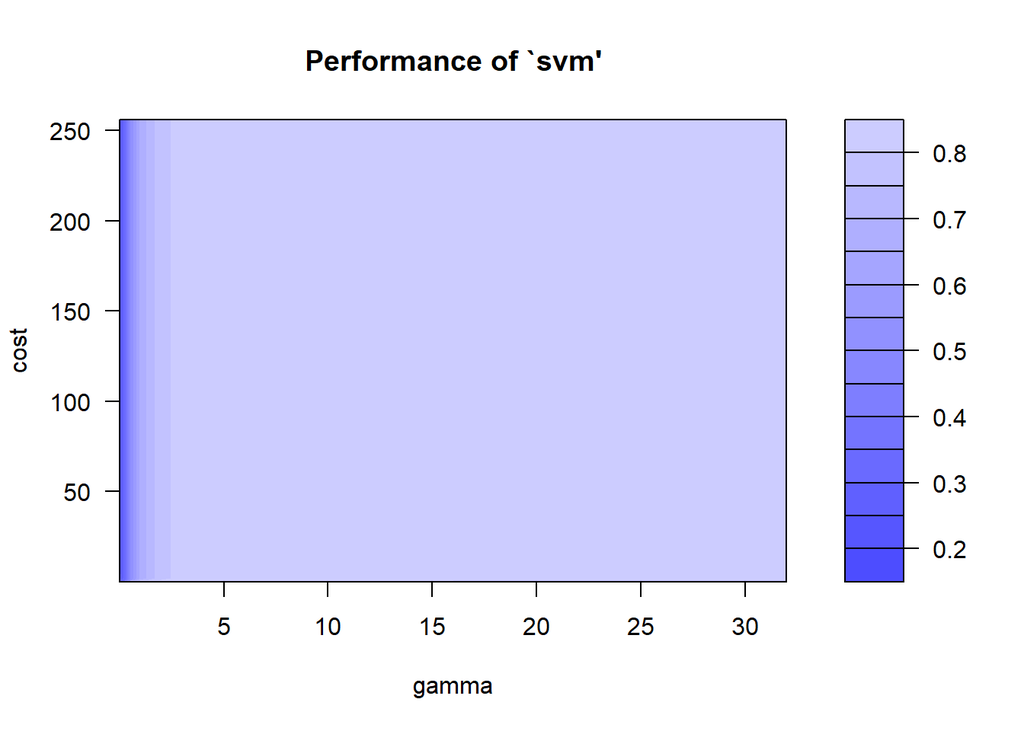

```r
plot(class.svm)
```

```r
gamma <- class.svm$best.model$gamma
cost <- class.svm$best.model$cost

# train model
svm.best <- svm(hym.extract[2:126], as.factor(hym.extract$species), gamma = gamma, cost = cost, probability = TRUE, cross=5)
```

## Task 6

The parameter cross stands for the partitions for cross-validation. Cross-validation is a technique in machine learning where the data is divided into subsets, and the model is trained and tested multiple times on different combinations of these subsets to obtain a more reliable performance evaluation. It helps assess a model’s ability to generalize to new data by simulating various training-test splits.

```r
hymap.class.svm <- terra::predict(hym, svm.best,
                  filename = "hymap_svm.tif",
                  overwrite = TRUE,type="prob"
                  #na.rm = T
)
```

## Task 7

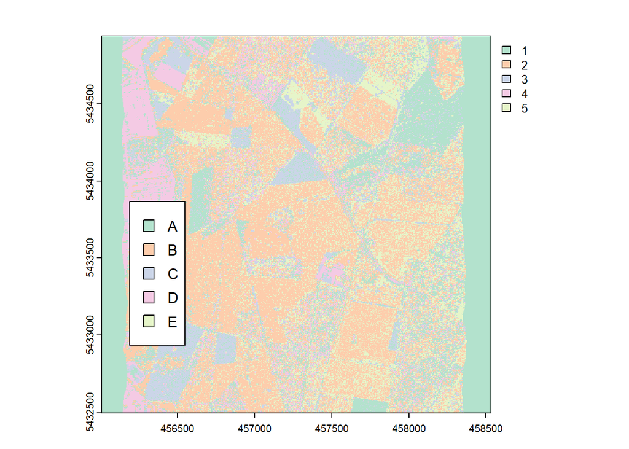

```r
colors = c('#b3e2cd','#fdcdac','#cbd5e8','#f4cae4','#e6f5c9')

plot(hymap.class.svm,col = colors)
legend(x="bottomleft", c("A","B","C","D","E"),inset=0.18,fill = colors,bg="white",cex=1.0)
```

```r
library("randomForest")
class.tunerf <- tuneRF(hym.extract[,2:116],
                  as.factor(hym.extract$species),
                  mtryStart = 5,
                  ntree = 1000,
                  importance=T,
                  doBest = T
                  )
```

```
## mtry = 5  OOB error = 28.8%
## Searching left ...
## mtry = 3     OOB error = 28.4%
## 0.01388889 0.05
## Searching right ...
## mtry = 10    OOB error = 28.4%
## 0.01388889 0.05
```

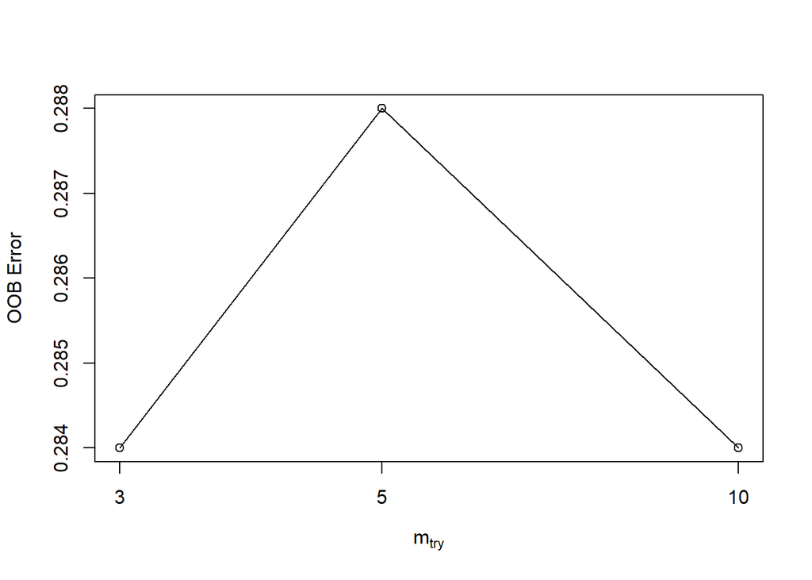

```r
# Let's have a look at the performance of the best model:
class.tunerf
```

```
##
## Call:
##  randomForest(x = x, y = y, mtry = res[which.min(res[, 2]), 1],      importance = ..1)
##                Type of random forest: classification
##                      Number of trees: 500
## No. of variables tried at each split: 3
##
##         OOB estimate of  error rate: 30.4%
## Confusion matrix:
##    1  2  3  4  5 class.error
## 1 27  2 16  4  1        0.46
## 2  3 38  0  0  9        0.24
## 3 11  1 35  3  0        0.30
## 4  5  0  3 42  0        0.16
## 5  2 13  1  2 32        0.36
```

## Task 8

The Confusion Matrix shows that the first class is the least accurate predicted class while as the 4th class is the most accurately predicted.

```r
hymap.class.rf.call1 <- terra::predict(hym, class.tunerf,
                  filename = "hymap_svm_call1.tif",
                  overwrite = TRUE,type="prob"
                  #na.rm = T
)

# Call2:
hymap.class.rf.call2 <- terra::predict(hym, class.tunerf,
                  filename = "hymap_svm2_call2.tif",
                  overwrite = TRUE
                  #na.rm =T
)
```

The Difference betweent the two function calls is the argument type = “prob” , with type=“prob” we will obtain 5 different Rasters with the probability of the pixel being classified as the corresponding category. While on the other function call we obtain one raster with pixels being assigned one of 5 discrete values it is classified as.

## Task 9

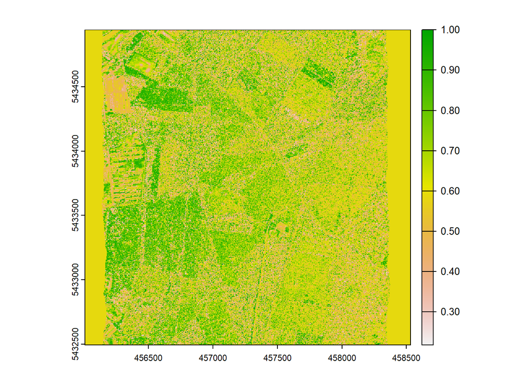

```r
probability = app(hymap.class.rf.call1,"max")

plot(probability)
```

## Task 10

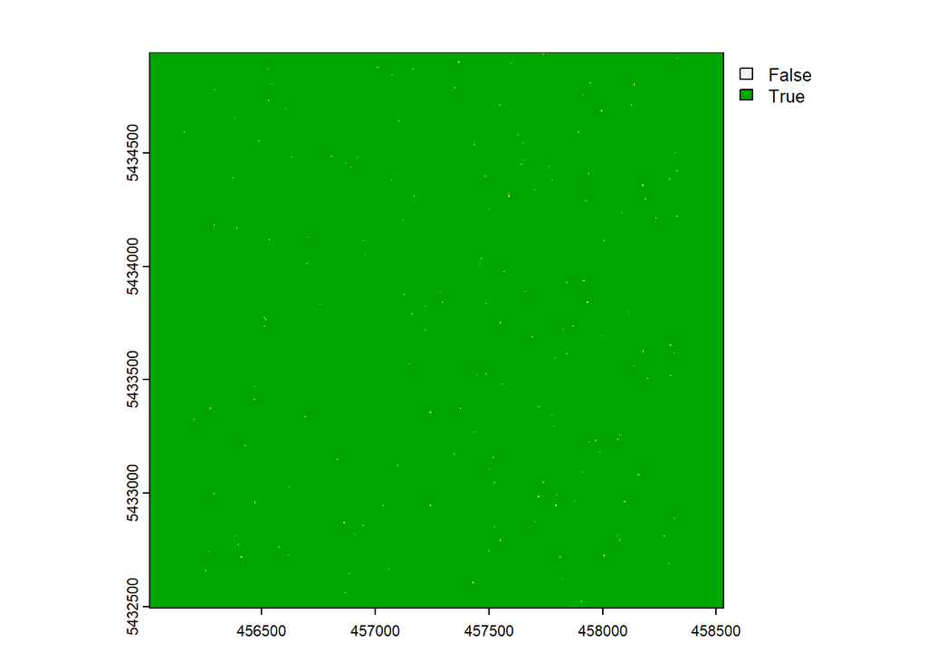

```r
majorityvote = app(hymap.class.rf.call1,"which.max")

plot(majorityvote == hymap.class.rf.call2)
```

## Task 11

To potentially compare the classification we would need to have a large enough subset where we correctly know the classes so that we could compare the correct classes to the predicted classes and then by the law of large numbers say which one is more accurate. Because of the way Machine Learning works the better algorithm would heavily depend on the dataset though. So a generalized statement cannot be made. The better statements can be made about the Calculation Speed and how it scales in Big-O notation.